# T Tests

```r
setwd("C:/Users/dania/Documents/Pitt/Biostats/Module 1")
#this is basically where we're saving the data

mice <- read.table("mouse_volumes.txt",sep="\t",header=T)
#name of file; sep says that it's tab delimited; header says that's the where the titles of the vraiables are
mice
```

```
##        trt Mouse.ID log.vol    vol  X
## 1  Control   4NVA1T   1.032  9.758 NA
## 2  Control   4NVA2T   0.862  6.273 NA
## 3  Control   4NVA3T   1.282 18.144 NA
## 4  Control   4NVB1T   1.166 13.664 NA
## 5  Control   4NVB2T   1.023  9.546 NA
## 6  Control   4NVB3T   1.159 13.438 NA
## 7  Control   4NVB4T   0.000  0.000 NA
## 8  Control   4NVB5T   0.546  2.512 NA
## 9  Control   4NVC1T   1.139 12.758 NA
## 10 Control   4NVC2T   0.501  2.168 NA
## 11 Control   4NVC3T   0.347  1.224 NA
## 12 Control   4NVC4T   0.469  1.944 NA
## 13 Control   4NVD1T   1.108 11.831 NA
## 14 Control   4NVD2T   0.727  4.331 NA
## 15 Control   4NVD3T   1.457 27.640 NA
## 16      SF   4NSE1T   0.000  0.000 NA
## 17      SF   4NSE2T   0.621  3.179 NA
## 18      SF   4NSE3T   0.252  0.786 NA
## 19      SF   4NSE4T   0.230  0.700 NA
## 20      SF   4NSE5T   0.610  3.078 NA
## 21      SF   4NSF1T   0.659  3.564 NA
## 22      SF   4NSF2T   0.767  4.851 NA
## 23      SF   4NSF3T   0.374  1.368 NA
## 24      SF   4NSF4T   0.000  0.000 NA
## 25      SF   4NSF5T   0.000  0.000 NA
## 26      SF   4NSG1T   0.266  0.847 NA
## 27      SF   4NSG2T   0.984  8.640 NA
## 28      SF   4NSG3T   0.160  0.446 NA
## 29      SF   4NSG4T   1.063 10.570 NA
## 30      SF   4NSH2T   0.279  0.900 NA
## 31      SF   4NSH3T   0.000  0.000 NA
## 32      SF   4NSH4T   0.866  6.348 NA
##                                                                                                                                  X.1
## 1                         Added volumes together from other sheet, did a log transformation -> took value, added one, and took log10
## 2                                                                                                                 GraphPad -> column
## 3  unpaired because theyre separate animals\nControl\t4NVA4T\t1.26\t17.188\t\tuse parametric test\nControl\t4NVA5T\t0\t0\t\tuse Welchs variant
## 4
## 5
## 6
```

[output cut: 11 more lines]

```
## 18
## 19
## 20
## 21
## 22
## 23
## 24
## 25
## 26
## 27
## 28
## 29
## 30
## 31
## 32
```

```r
class(mice)
```

```
## [1] "data.frame"
```

```r
#tells you what you're looking at, what format the data is in
#with(mice,plot(log.vol~trt,xlim=NULL,na.rm=T))
#we're plotting the log volume as a function of the treatment
#with just means pull the data from the mice dataset
#like a regular box plot, dark line is the median, bottom of box is first quartile, top of box is third quartile
#with(mice,points(log.vol~trt,na.rm=T))
#points gives you actual data points
```

##Welch’s T Test## Basically a two sample Student’s t test with the Welch’s correction to account for different standard deviations among samples.

```r
with(mice,t.test(log.vol~trt)) #Welch's variant, default in R
```

```
##
##  Welch Two Sample t-test
##
## data:  log.vol by trt
## t = 3.1885, df = 28.227, p-value = 0.003485
## alternative hypothesis: true difference in means is not equal to 0
## 95 percent confidence interval:
##  0.1556626 0.7144629
## sample estimates:
## mean in group Control      mean in group SF
##             0.8545333             0.4194706
```

```r
with(mice,t.test(log.vol~trt,var.equal=T))
```

```
##
##  Two Sample t-test
##
## data:  log.vol by trt
## t = 3.2138, df = 30, p-value = 0.003126
## alternative hypothesis: true difference in means is not equal to 0
## 95 percent confidence interval:
##  0.1585910 0.7115345
## sample estimates:
## mean in group Control      mean in group SF
##             0.8545333             0.4194706
```

**two tailed** tests are the default for R, as noted by the “alternative=” option in the function. To do a one-tailed test, change alternative to “greater” or “less;” one-tailed tests are less stringent than two-tailed tests and give a p value that is approximately half of what a two-tailed test would give

```r
with(mice,t.test(log.vol~trt,alternative="greater",var.equal=T))
```

```
##
##  Two Sample t-test
##
## data:  log.vol by trt
## t = 3.2138, df = 30, p-value = 0.001563
## alternative hypothesis: true difference in means is greater than 0
## 95 percent confidence interval:
##  0.2052968       Inf
## sample estimates:
## mean in group Control      mean in group SF
##             0.8545333             0.4194706
```

##Paired Comparison tests## These compare individual patients over time, for example, before and after treatment.

```r
setwd("C:/Users/dania/Documents/Pitt/Biostats/Module 1")
patients <- read.table("CA19-9.txt",sep="\t",header=T)
treated <- patients[patients$HCQ==1,] #not interested in controls because patients are compared to themselves
treated
```

```
##    HCQ CA.19.Post CA.19.Pre log.CA.19.Post log.CA.19.Pre
## 2    1      358.2    2327.8          2.554         3.367
## 5    1        7.5     271.2          0.875         2.433
## 6    1        8.4      47.0          0.924         1.672
## 7    1       15.3    1570.7          1.185         3.196
## 8    1       37.8     302.6          1.577         2.481
## 10   1       24.3     336.3          1.386         2.527
## 12   1        0.8       8.0         -0.097         0.903
## 13   1      160.6    2881.2          2.206         3.460
## 15   1        4.0       0.8          0.602        -0.097
## 25   1       25.9     108.8          1.413         2.037
## 26   1       14.2      32.1          1.152         1.507
## 28   1       13.8     148.5          1.140         2.172
## 30   1        6.9     201.2          0.839         2.304
## 31   1        8.1     199.3          0.908         2.300
```

[output cut: 20 more lines]

```r
before <- treated$log.CA.19.Pre
after <- treated$log.CA.19.Post

t.test(before,after,paired=T) #two tailed
```

```
##
##  Paired t-test
##
## data:  before and after
## t = 6.3439, df = 33, p-value = 3.519e-07
## alternative hypothesis: true difference in means is not equal to 0
## 95 percent confidence interval:
##  0.6351592 1.2348996
## sample estimates:
## mean of the differences
##               0.9350294
```

##Creating a Linear Model## We can use the linear model to look at normality, residuals, etc. We can run the linear model on the log(volume) to look at outliers on the residual plots, then rerun the model with the actual volumes to identify the outliers.

```r
lm1 <- with(mice,lm(log.vol~trt))
lm1 <- with(mice,lm(vol~trt))
summary(lm1)
```

```
##
## Call:
## lm(formula = vol ~ trt)
##
## Residuals:
##    Min     1Q Median     3Q    Max
## -9.015 -2.663 -1.529  3.033 18.625
##
## Coefficients:
##             Estimate Std. Error t value Pr(>|t|)
## (Intercept)    9.015      1.469   6.136 9.54e-07 ***
## trtSF         -6.352      2.016  -3.151  0.00367 **
## ---
## Signif. codes:  0 '***' 0.001 '**' 0.01 '*' 0.05 '.' 0.1 ' ' 1
##
## Residual standard error: 5.69 on 30 degrees of freedom
## Multiple R-squared:  0.2487, Adjusted R-squared:  0.2236
## F-statistic:  9.93 on 1 and 30 DF,  p-value: 0.003671
```

```r
class(lm1) #lists all of the data classes that we can look at
```

```
## [1] "lm"
```

```r
lm1$residuals #residuals will help us identify how Gaussian the data is
```

```
##          1          2          3          4          5          6          7
##  0.7426000 -2.7424000  9.1286000  4.6486000  0.5306000  4.4226000 -9.0154000
##          8          9         10         11         12         13         14
## -6.5034000  3.7426000 -6.8474000 -7.7914000 -7.0714000  2.8156000 -4.6844000
##         15         16         17         18         19         20         21
## 18.6246000 -2.6633529  0.5156471 -1.8773529 -1.9633529  0.4146471  0.9006471
##         22         23         24         25         26         27         28
##  2.1876471 -1.2953529 -2.6633529 -2.6633529 -1.8163529  5.9766471 -2.2173529
##         29         30         31         32
##  7.9066471 -1.7633529 -2.6633529  3.6846471
```

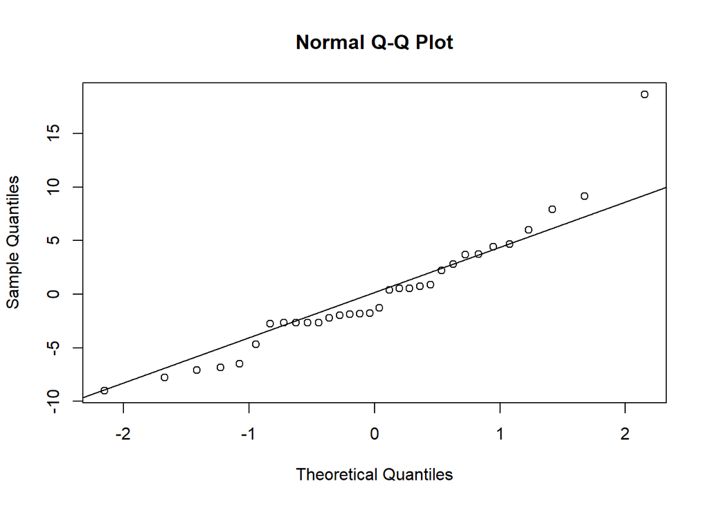

```r
qqnorm(lm1$residuals)
qqline(lm1$residuals)
```

```r
#the closer the residuals are to the line, the more Gaussian the data are
```

The **Wilcoxon test** is a nonparametric test that can be run in place of a t test, using rank instead of numeric values. This test has fewer assumptions than parametric tests and are helpful when data does not have a Gaussian distribution. The Wilcoxon test is an alternative for the two sample t test.

```r
with(mice,wilcox.test(log.vol~trt))
```

```
##
##  Wilcoxon rank sum test with continuity correction
##
## data:  log.vol by trt
## W = 202, p-value = 0.005117
## alternative hypothesis: true location shift is not equal to 0
```

```r
#R calls test statistic W instead of T
with(mice,wilcox.test(vol~trt))
```

```
##
##  Wilcoxon rank sum test with continuity correction
##
## data:  vol by trt
## W = 202, p-value = 0.005117
## alternative hypothesis: true location shift is not equal to 0
```

```r
#these will be the same because the ranks for the vol and log.vol will be the same
```

Another nonparametric alternative is the **signed rank test** which is an alternative to the one sample t test or paired comparison test.

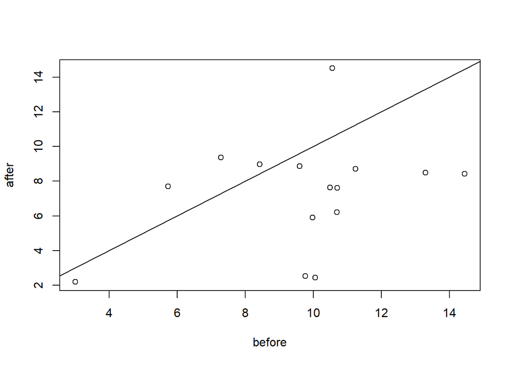

```r
set.seed(1953)
#random number generator
before <- rnorm(15,10,3)
after <- rnorm(15,7,3)
#random normal (#, mean, SD) of observations
plot(before,after)
abline(a=0,b=1)
```

```r
wilcox.test(before,after,paired=T)
```

```
##
##  Wilcoxon signed rank exact test
##
## data:  before and after
## V = 101, p-value = 0.01807
## alternative hypothesis: true location shift is not equal to 0
```

```r
#default is paired=F
```